# R Markdown

Lubaba Ferdous Alim

2023-11-19

```r
require(ggplot2)
require(GGally)
require(MASS)
require(car)
library(leaps)
data = read.table("Plasma.txt", header = TRUE)
(n = nrow(data))
```

```
## [1] 315
```

```r
(p = ncol(data))
```

```
## [1] 14
```

- 315 observations and 14 variables

```r
names(data) = c("age", "sex", "smokstat", "quetelet", "vituse", "calories", "fat", "fiber", "alcohol", "cholesterol", "betadiet", "retdiet", "betaplasma", "retplasma")
```

```r
sapply(data, function(x) sum(is.na(x)))
```

```
##         age         sex    smokstat    quetelet      vituse    calories
##           0           0           0           0           0           0
##         fat       fiber     alcohol cholesterol    betadiet     retdiet
##           0           0           0           0           0           0
##  betaplasma   retplasma
##           0           0
```

- no missing data

```r
sapply(data, class)
```

```
##         age         sex    smokstat    quetelet      vituse    calories
##   "integer" "character" "character"   "numeric" "character"   "numeric"
##         fat       fiber     alcohol cholesterol    betadiet     retdiet
##   "numeric"   "numeric"   "numeric"   "numeric"   "integer"   "integer"
##  betaplasma   retplasma
##   "integer"   "integer"
```

```r
data$sex = as.factor(data$sex)
data$smokstat = as.factor(data$smokstat)
data$vituse = as.factor(data$vituse)

sapply(data, class)
```

```
##         age         sex    smokstat    quetelet      vituse    calories
##   "integer"    "factor"    "factor"   "numeric"    "factor"   "numeric"
##         fat       fiber     alcohol cholesterol    betadiet     retdiet
##   "numeric"   "numeric"   "numeric"   "numeric"   "integer"   "integer"
##  betaplasma   retplasma
##   "integer"   "integer"
```

```r
table(data$sex)
```

```
##
## FEMALE   MALE
##    273     42
```

```r
table(data$smokstat)
```

```
##
## CURRENT  FORMER   NEVER
##      43     115     157
```

```r
table(data$vituse)
```

```
##
##        NO NOT OFTEN     OFTEN
##       111        82       122
```

```r
summary(data)
```

```
##       age            sex         smokstat      quetelet           vituse
##  Min.   :19.00   FEMALE:273   CURRENT: 43   Min.   :16.33   NO       :111
##  1st Qu.:39.00   MALE  : 42   FORMER :115   1st Qu.:21.80   NOT OFTEN: 82
##  Median :48.00                NEVER  :157   Median :24.74   OFTEN    :122
##  Mean   :50.15                              Mean   :26.16
##  3rd Qu.:62.50                              3rd Qu.:28.85
##  Max.   :83.00                              Max.   :50.40
##     calories           fat             fiber          alcohol
##  Min.   : 445.2   Min.   : 14.40   Min.   : 3.10   Min.   :  0.000
##  1st Qu.:1338.0   1st Qu.: 53.95   1st Qu.: 9.15   1st Qu.:  0.000
##  Median :1666.8   Median : 72.90   Median :12.10   Median :  0.300
##  Mean   :1796.7   Mean   : 77.03   Mean   :12.79   Mean   :  3.279
##  3rd Qu.:2100.4   3rd Qu.: 95.25   3rd Qu.:15.60   3rd Qu.:  3.200
##  Max.   :6662.2   Max.   :235.90   Max.   :36.80   Max.   :203.000
##   cholesterol       betadiet       retdiet         betaplasma
##  Min.   : 37.7   Min.   : 214   Min.   :  30.0   Min.   :   0.0
##  1st Qu.:155.0   1st Qu.:1116   1st Qu.: 480.0   1st Qu.:  90.0
##  Median :206.3   Median :1802   Median : 707.0   Median : 140.0
##  Mean   :242.5   Mean   :2186   Mean   : 832.7   Mean   : 189.9
##  3rd Qu.:308.9   3rd Qu.:2836   3rd Qu.:1037.0   3rd Qu.: 230.0
##  Max.   :900.7   Max.   :9642   Max.   :6901.0   Max.   :1415.0
##    retplasma
##  Min.   : 179.0
##  1st Qu.: 466.0
##  Median : 566.0
##  Mean   : 602.8
##  3rd Qu.: 716.0
##  Max.   :1727.0
```

- The maximum value with a single observation of the variable alcohol is 203. The next largest value is 35. This is most likely an outlier.
- The minimum value with a single observation of the variable betaplasma is 0. The next smallest value is 14. This is also likely an outlier.

```r
data = data[,-14]
```

**Exploratory Data Analysis**

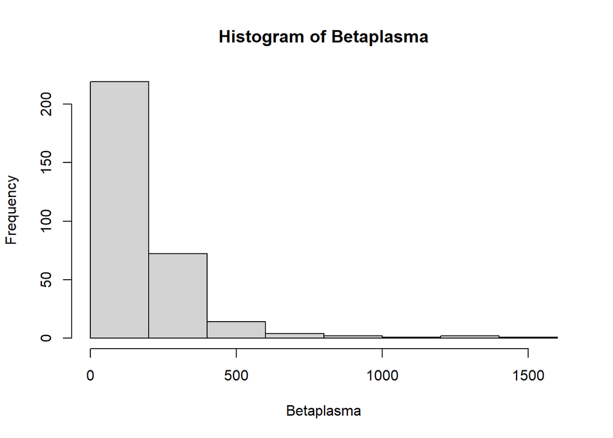

```r
hist(data$betaplasma, xlab = "Betaplasma", main = "Histogram of Betaplasma")
```

- The histogram of Betaplasma is heavily right tailed. A log transformation may be necessary.

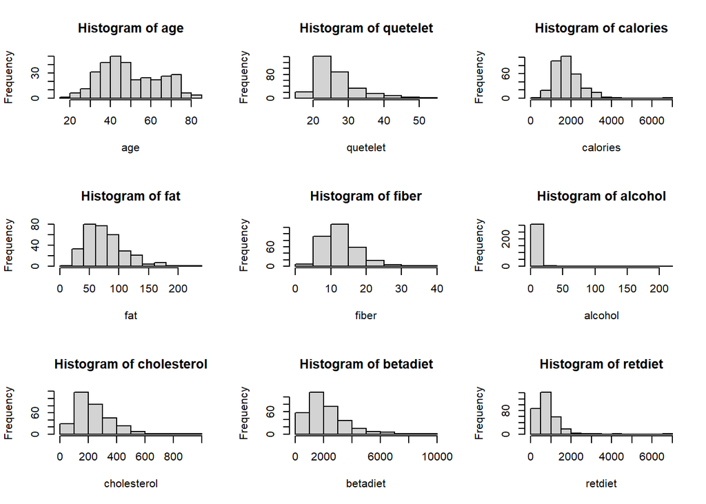

```r
par(mfrow = c(3, 3))
for(i in c(1,4,6:12)) {
hist(data[, i], main=paste("Histogram of", names(data)[i]), xlab = paste(names(data)[i]))}
```

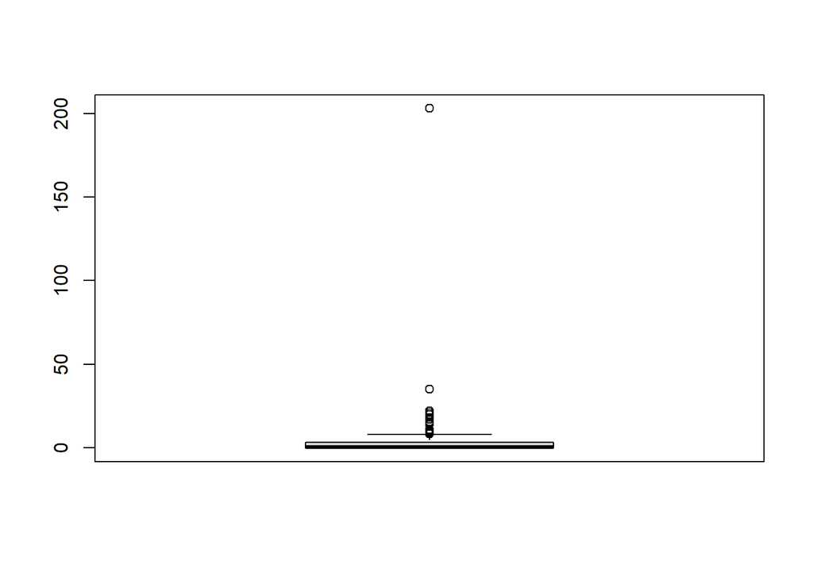

```r
boxplot(data$alcohol)
```

- The maximum value of alcohol consumption seems much higher than the rest of the values. This is potentially an outlier. It is ideal to see the distribution of alcohol consumption excluding this value.

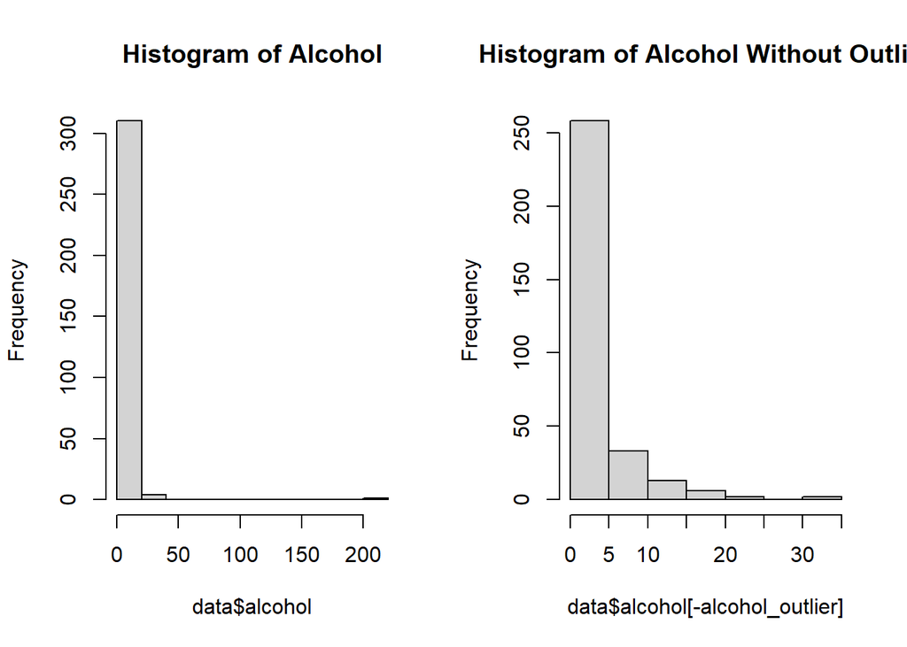

```r
alcohol_outlier=which(data$alcohol==203)
par(mfrow=c(1,2))
hist(data$alcohol, main="Histogram of Alcohol")
hist(data$alcohol[-alcohol_outlier], main="Histogram of Alcohol Without Outlier")
```

```r
data = data[-c(which(data$alcohol==203),which(data$betaplasma==0)),]
```

```r
# pairplot = ggpairs(data[c(1,4,6:13)], progress = F,
#                    lower = list(continuous = "cor", combo = "box_no_facet", discrete = "count", na = "na"),
#                    upper = list(continuous = "points", combo = "facethist", discrete = "facetbar", na = "na"))
#
# pairplot
```

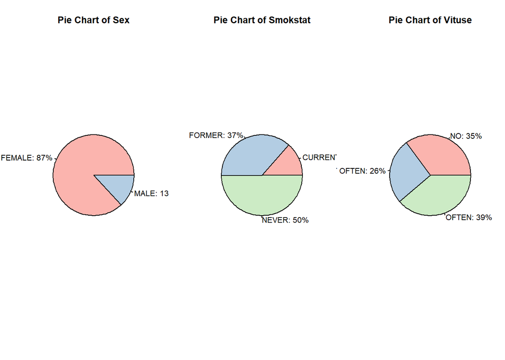

```r
par(mfrow=c(1,3))
lab_sex = levels(data$sex)
pcent_sex = round(100*table(data$sex)/nrow(data))
lab_sex = paste0(lab_sex, ": ", pcent_sex, "%")

pie(table(data$sex), labels = lab_sex, main = "Pie Chart of Sex", col = palette.colors(palette = "Pastel 1"))

lab_smokstat = levels(data$smokstat)
pcent_smokstat = round(100*table(data$smokstat)/nrow(data))
lab_smokstat = paste0(lab_smokstat, ": ", pcent_smokstat, "%")


pie(table(data$smokstat), labels = lab_smokstat, main = "Pie Chart of Smokstat", col = palette.colors(palette = "Pastel 1"))

lab_vituse = levels(data$vituse)
pcent_vituse = round(100*table(data$vituse)/nrow(data))
lab_vituse = paste0(lab_vituse, ": ", pcent_vituse, "%")


pie(table(data$vituse), labels = lab_vituse, main = "Pie Chart of Vituse", col = palette.colors(palette = "Pastel 1"))
```

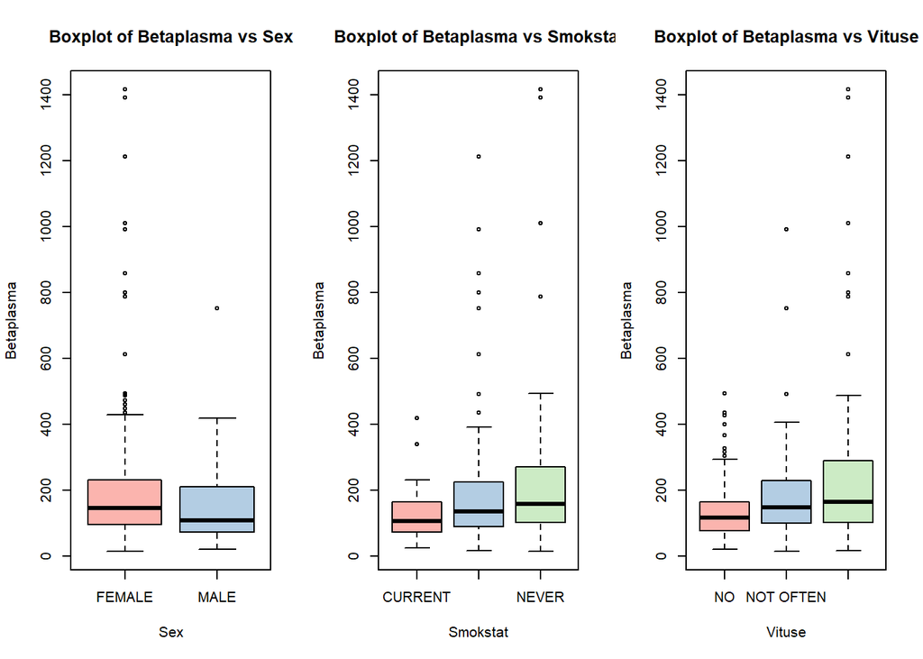

```r
par(mfrow=c(1,3))
boxplot(data$betaplasma~data$sex, main = "Boxplot of Betaplasma vs Sex", xlab = "Sex", ylab = "Betaplasma", col = palette.colors(palette = "Pastel 1"))
boxplot(data$betaplasma~data$smokstat, main = "Boxplot of Betaplasma vs Smokstat", xlab = "Smokstat", ylab = "Betaplasma", col = palette.colors(palette = "Pastel 1"))
boxplot(data$betaplasma~data$vituse, main = "Boxplot of Betaplasma vs Vituse", xlab = "Vituse", ylab = "Betaplasma", col = palette.colors(palette = "Pastel 1"))
```

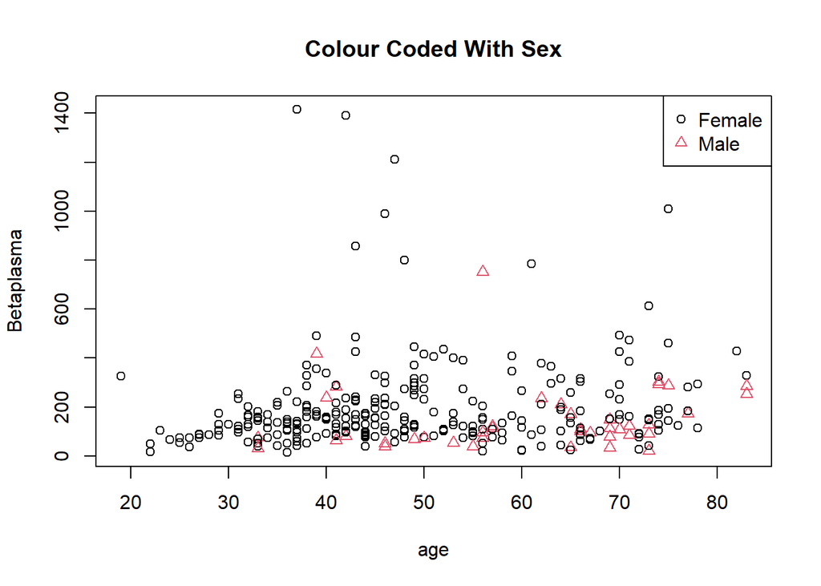

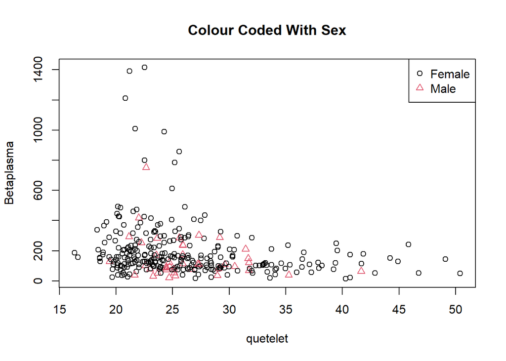

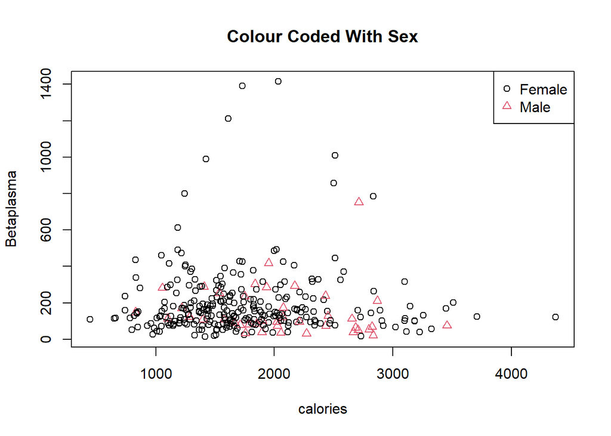

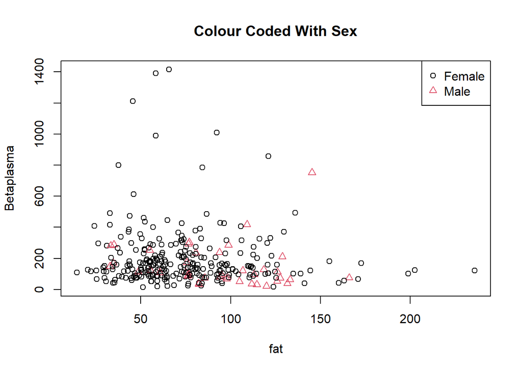

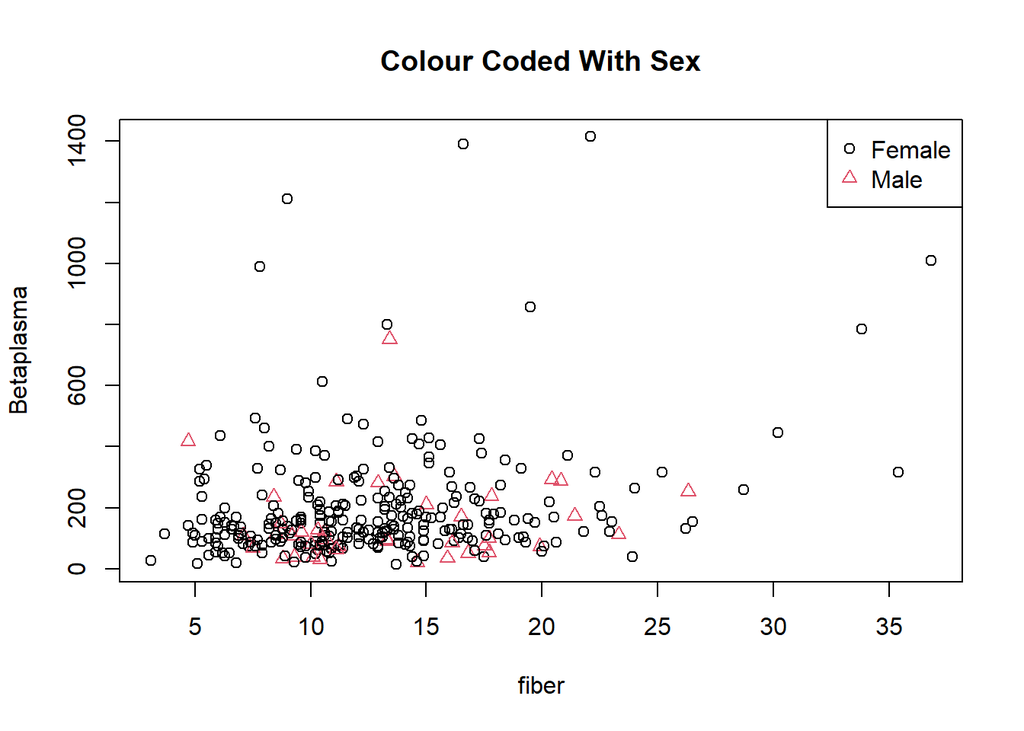

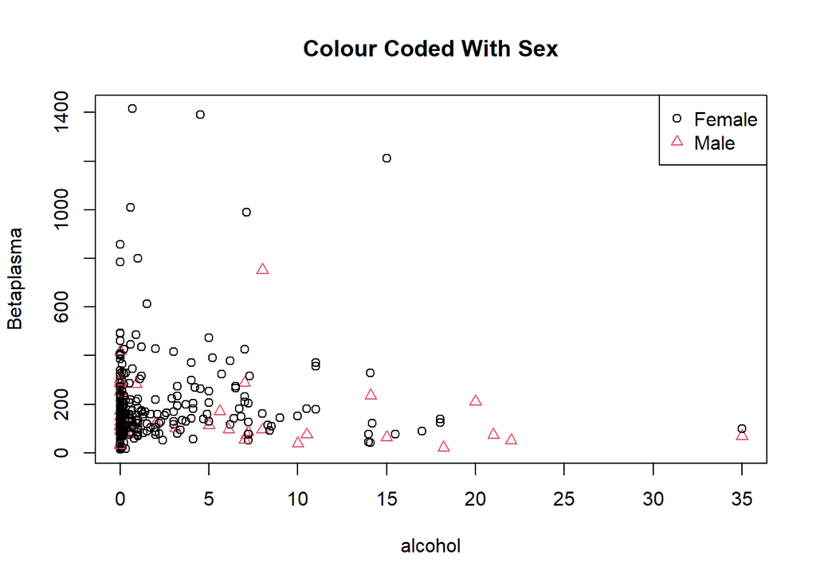

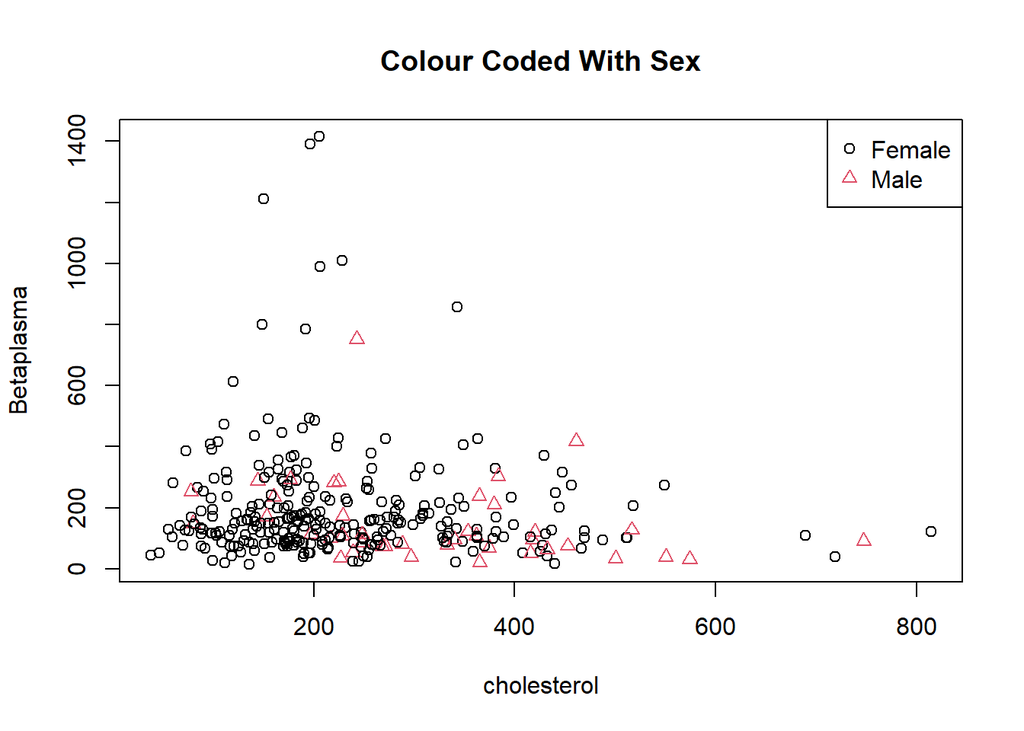

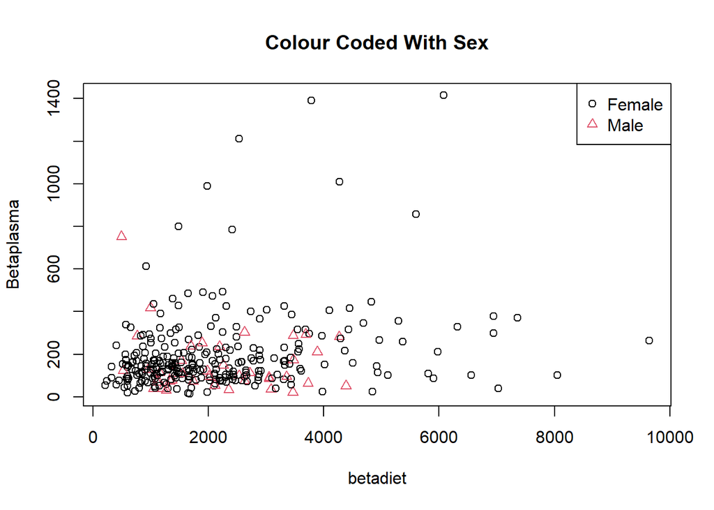

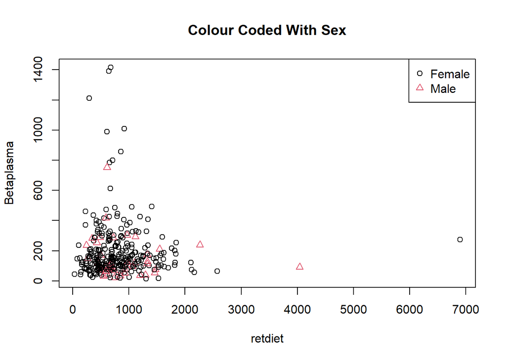

```r
for(i in c(1,4,6:12)){
  plot(data[,i], data$betaplasma, pch = as.integer(data$sex), col = as.integer(data$sex), main = "Colour Coded With Sex",ylab = "Betaplasma", xlab = paste(names(data)[i]))
legend('topright', legend = c("Female","Male"),pch=c(1,2),col=c(1,2))
}
```

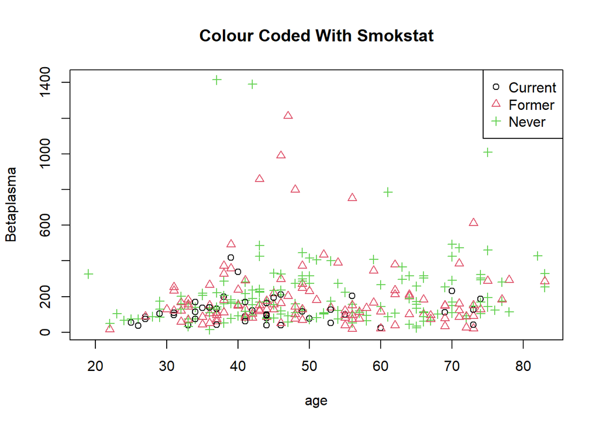

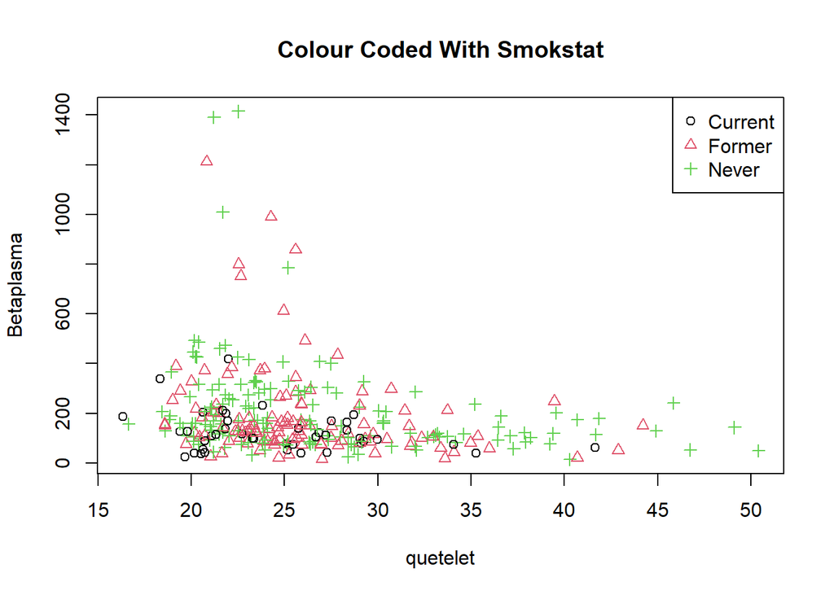

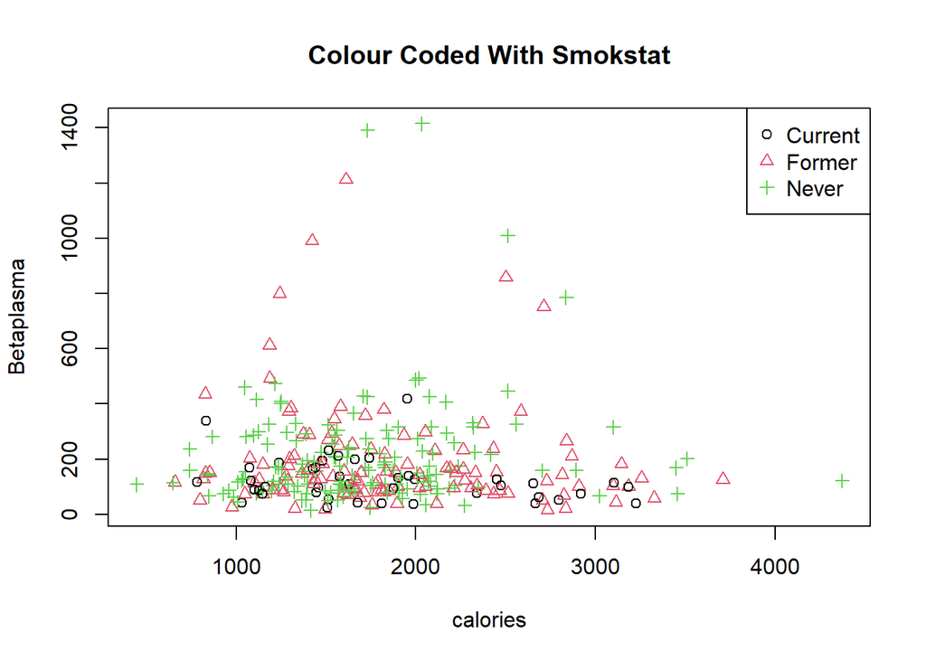

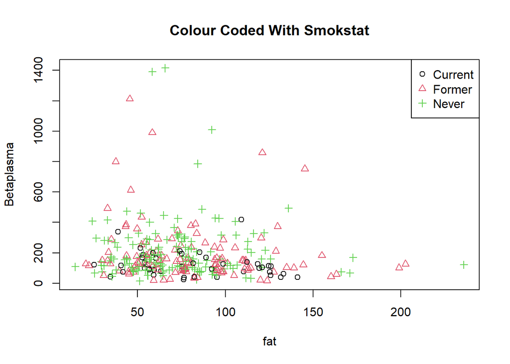

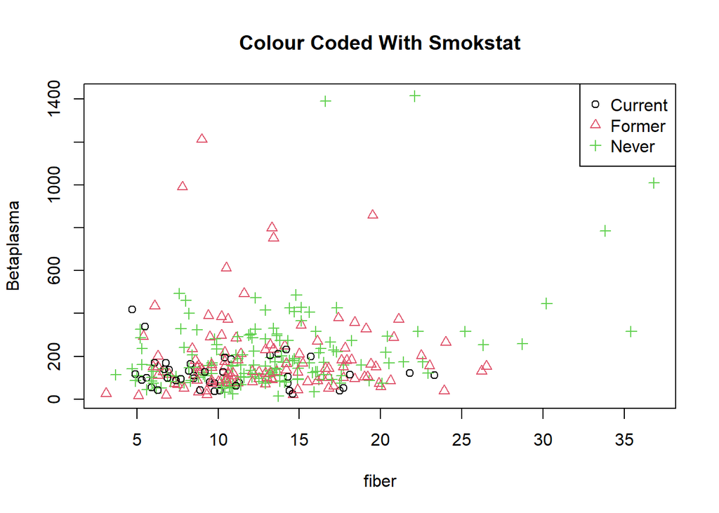

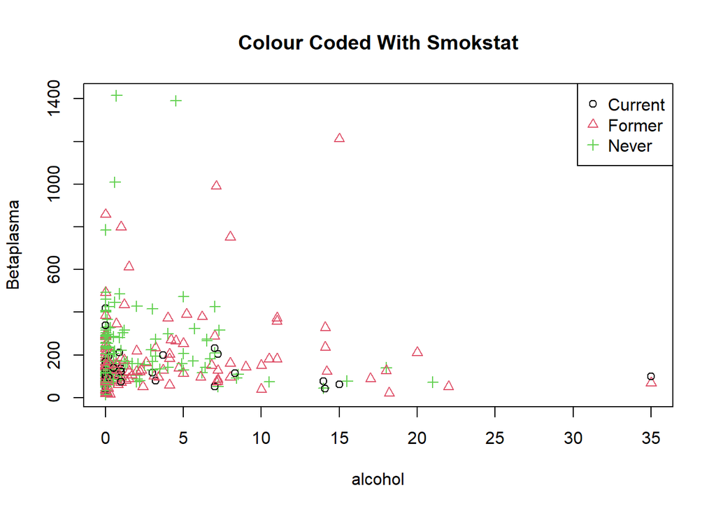

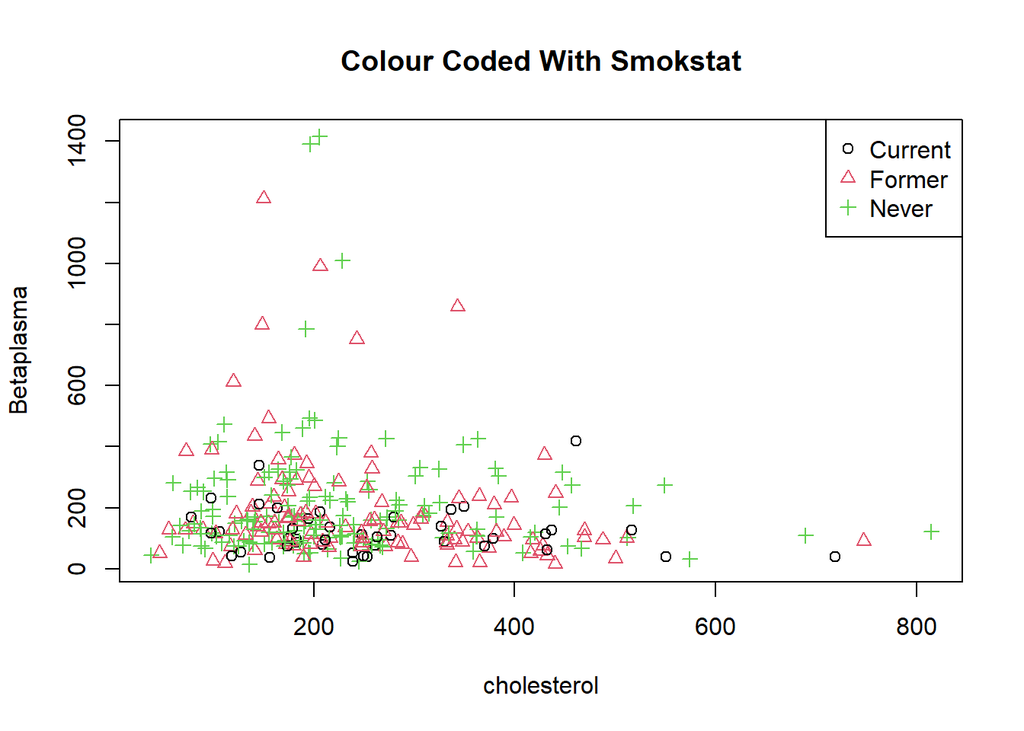

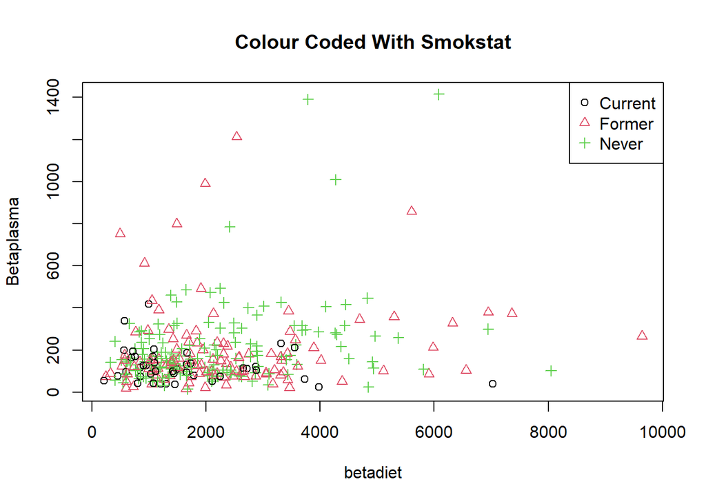

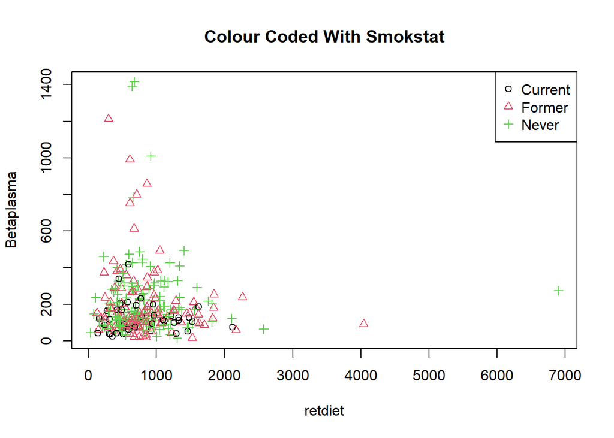

```r
for(i in c(1,4,6:12)){
  plot(data[,i], data$betaplasma, pch = as.integer(data$smokstat), col = as.integer(data$smokstat), main = "Colour Coded With Smokstat",ylab = "Betaplasma", xlab = paste(names(data)[i]))
legend('topright', legend = c("Current","Former", "Never"),pch=c(1,2,3),col=c(1,2,3))
}
```